# Predictive Policing Homework

Yuhao Jia

10/18/2022

# 1.Set Up

Set up packages.

```r
knitr::opts_chunk$set(echo = TRUE, warning=FALSE)

library(tidyverse)
library(sf)
library(RSocrata)
library(viridis)
library(spatstat)
library(raster)
library(spdep)
library(FNN)
library(grid)
library(gridExtra)
library(knitr)
library(kableExtra)
library(tidycensus)
library(classInt)   # for KDE and ML risk class intervals
# functions
root.dir = "https://raw.githubusercontent.com/urbanSpatial/Public-Policy-Analytics-Landing/master/DATA/"
source("https://raw.githubusercontent.com/urbanSpatial/Public-Policy-Analytics-Landing/master/functions.r")
```

# 2. Data Wrangling

## Crime Data from Chicago

The crime of sexual assault of 2017 in Chicago was chosen as the outcome of predict policing. Differing from burglary, incidents of sexual assault are recorded primarily from reports of victims. Many victims of sexual assault do not choose to report the crime for various reasons such as fear and shame, which is the selection bias of this type of crime.

```r
policeDistricts <-
  st_read("https://data.cityofchicago.org/api/geospatial/fthy-xz3r?method=export&format=GeoJSON") %>%
  st_transform('ESRI:102271') %>%
  dplyr::select(District = dist_num)

policeBeats <-
  st_read("https://data.cityofchicago.org/api/geospatial/aerh-rz74?method=export&format=GeoJSON") %>%
  st_transform('ESRI:102271') %>%
  dplyr::select(District = beat_num)

bothPoliceUnits <- rbind(mutate(policeDistricts, Legend = "Police Districts"),
                         mutate(policeBeats, Legend = "Police Beats"))

S_ASSAULT <-
  read.socrata("https://data.cityofchicago.org/Public-Safety/Crimes-2017/d62x-nvdr") %>%
    filter(Primary.Type == "CRIM SEXUAL ASSAULT" ) %>%
    mutate(x = gsub("[()]", "", Location)) %>%
    separate(x,into= c("Y","X"), sep=",") %>%
    mutate(X = as.numeric(X),Y = as.numeric(Y)) %>%
    na.omit() %>%
    st_as_sf(coords = c("X", "Y"), crs = 4326, agr = "constant")%>%
    st_transform('ESRI:102271') %>%
    distinct()

chicagoBoundary <-
  st_read(file.path(root.dir,"/Chapter5/chicagoBoundary.geojson")) %>%
  st_transform('ESRI:102271')
```

## visualizing sexual assault

Below is the map of the distribution of sexual assault. The center city area has the highest density.

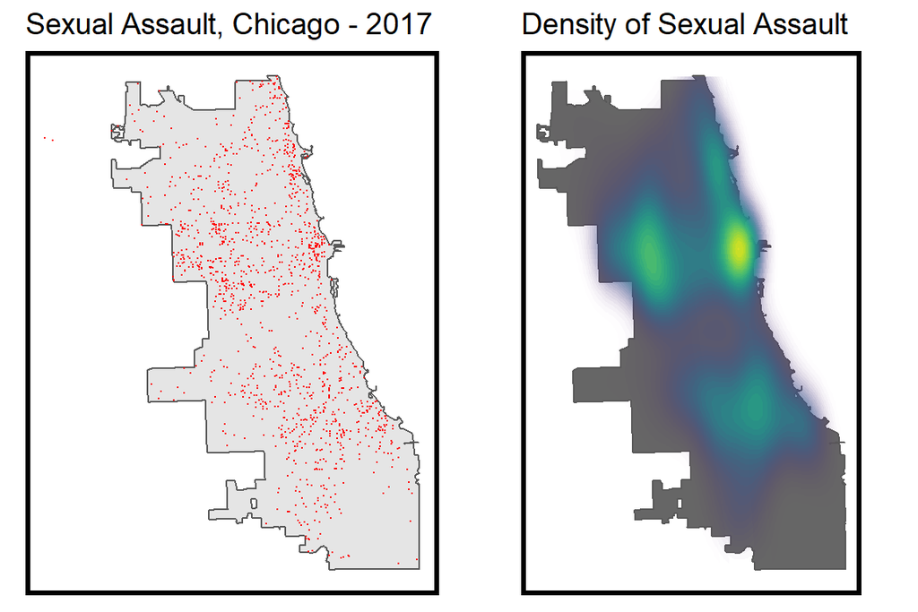

```r
# uses grid.arrange to organize independent plots
grid.arrange(ncol=2,
ggplot() +
  geom_sf(data = chicagoBoundary) +
  geom_sf(data = S_ASSAULT, colour="red", size=0.1, show.legend = "point") +
  labs(title= "Sexual Assault, Chicago - 2017") +
  mapTheme(title_size = 14),

ggplot() +
  geom_sf(data = chicagoBoundary, fill = "grey40") +
  stat_density2d(data = data.frame(st_coordinates(S_ASSAULT)),
                 aes(X, Y, fill = ..level.., alpha = ..level..),
                 size = 0.01, bins = 40, geom = 'polygon') +
  scale_fill_viridis() +
  scale_alpha(range = c(0.00, 0.35), guide = FALSE) +
  labs(title = "Density of Sexual Assault") +
  mapTheme(title_size = 14) + theme(legend.position = "none"))
```

## Creating a fishnet grid

A fishnet was created based on the Chicago boundary. The sexual assault incidents was counted in each grid.

```r
fishnet <-
  st_make_grid(chicagoBoundary,
               cellsize = 500,
               square = TRUE) %>%
  .[chicagoBoundary] %>%            # fast way to select intersecting polygons
  st_sf() %>%
  mutate(uniqueID = 1:n())
```

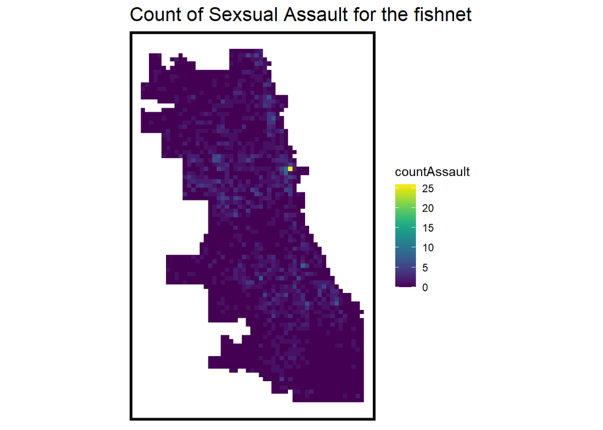

```r
## add a value of 1 to each crime, sum them with aggregate
crime_net <-
  dplyr::select(S_ASSAULT) %>%
  mutate(countAssault = 1) %>%
  aggregate(., fishnet, sum) %>%
  mutate(countAssault = replace_na(countAssault, 0),
         uniqueID = 1:n(),
         cvID = sample(round(nrow(fishnet) / 24),
                       size=nrow(fishnet), replace = TRUE))

ggplot() +
  geom_sf(data = crime_net, aes(fill = countAssault), color = NA) +
  scale_fill_viridis() +
  labs(title = "Count of Sexsual Assault for the fishnet") +
  mapTheme()
```

## Modeling Spatial Features

Here, based on the broken window theory, five categories of data related to the degree of urban decay were selected (abandon Cars,street Lights Out,abandon Buildings, graffiti, sanitation). In addition, the location of liquor stores may also be associated with crime.

```r
## Features
abandonCars <-
  read.socrata("https://data.cityofchicago.org/Service-Requests/311-Service-Requests-Abandoned-Vehicles/3c9v-pnva") %>%
    mutate(year = substr(creation_date,1,4)) %>% filter(year == "2017") %>%
    dplyr::select(Y = latitude, X = longitude) %>%
    na.omit() %>%
    st_as_sf(coords = c("X", "Y"), crs = 4326, agr = "constant") %>%
    st_transform(st_crs(fishnet)) %>%
    mutate(Legend = "Abandoned_Cars")

abandonBuildings <-
  read.socrata("https://data.cityofchicago.org/Service-Requests/311-Service-Requests-Vacant-and-Abandoned-Building/7nii-7srd") %>%
    mutate(year = substr(date_service_request_was_received,1,4)) %>%  filter(year == "2017") %>%
    dplyr::select(Y = latitude, X = longitude) %>%
    na.omit() %>%
    st_as_sf(coords = c("X", "Y"), crs = 4326, agr = "constant") %>%
    st_transform(st_crs(fishnet)) %>%
    mutate(Legend = "Abandoned_Buildings")

graffiti <-
  read.socrata("https://data.cityofchicago.org/Service-Requests/311-Service-Requests-Graffiti-Removal-Historical/hec5-y4x5") %>%
    mutate(year = substr(creation_date,1,4)) %>% filter(year == "2017") %>%
    filter(where_is_the_graffiti_located_ %in% c("Front", "Rear", "Side")) %>%
    dplyr::select(Y = latitude, X = longitude) %>%
    na.omit() %>%
    st_as_sf(coords = c("X", "Y"), crs = 4326, agr = "constant") %>%
    st_transform(st_crs(fishnet)) %>%
    mutate(Legend = "Graffiti")

streetLightsOut <-
  read.socrata("https://data.cityofchicago.org/Service-Requests/311-Service-Requests-Street-Lights-All-Out/zuxi-7xem") %>%
    mutate(year = substr(creation_date,1,4)) %>% filter(year == "2017") %>%
    dplyr::select(Y = latitude, X = longitude) %>%
    na.omit() %>%
    st_as_sf(coords = c("X", "Y"), crs = 4326, agr = "constant") %>%
    st_transform(st_crs(fishnet)) %>%
    mutate(Legend = "Street_Lights_Out")

sanitation <-
  read.socrata("https://data.cityofchicago.org/Service-Requests/311-Service-Requests-Sanitation-Code-Complaints-Hi/me59-5fac") %>%
    mutate(year = substr(creation_date,1,4)) %>% filter(year == "2017") %>%
    dplyr::select(Y = latitude, X = longitude) %>%
    na.omit() %>%
    st_as_sf(coords = c("X", "Y"), crs = 4326, agr = "constant") %>%
    st_transform(st_crs(fishnet)) %>%
    mutate(Legend = "Sanitation")

liquorRetail <-
  read.socrata("https://data.cityofchicago.org/resource/nrmj-3kcf.json") %>%
    filter(business_activity == "Retail Sales of Packaged Liquor") %>%
    dplyr::select(Y = latitude, X = longitude) %>%
    na.omit() %>%
    st_as_sf(coords = c("X", "Y"), crs = 4326, agr = "constant") %>%
    st_transform(st_crs(fishnet)) %>%
    mutate(Legend = "Liquor_Retail")

Zoning <-
  st_read("D:/UPenn/Fall2022/5080Policy/HW_data/Boundaries - Zoning Districts (current)/geo_export_4bb7997b-964c-4d40-8fd7-002b5cec0faa.shp")%>%
    dplyr::select(zone_type) %>%
    st_transform(st_crs(fishnet)) %>%
    mutate(Legend = "Zoning")
Zoning$zone_type[Zoning$zone_type == 8 |Zoning$zone_type == 9 ] <- 7
Zoning$zone_type <- as.character(Zoning$zone_type)


census_api_key("5398912e4e9370d9d6c91b1e4d2c80b53eee8001", overwrite  = TRUE)
female2017 <-
  get_acs(geography = "block group",
          variables = c("B01001_031E","B01001_032E",
                        "B01001_033E","B01001_034E",
                        "B01001_035E","B01001_036E",
                        "B01001_037E"),
          year=2017, state= 17, county=031,
          geometry=TRUE, output="wide") %>%
  mutate(female15_40 = B01001_031E+B01001_032E+B01001_033E+B01001_034E+B01001_035E+B01001_036E+B01001_037E) %>%
  dplyr::select(female15_40) %>%
  mutate(Legend = "Female") %>%
  st_transform(st_crs(fishnet))



## Neighborhoods to use in LOOCV in a bit
neighborhoods <-
  st_read("https://raw.githubusercontent.com/blackmad/neighborhoods/master/chicago.geojson") %>%
  st_transform(st_crs(fishnet))
```

# 3.Feature Engineering

## Nearest Neighbor Feature

K nearest neighbor was used to calculate the average distance of nearest features for each grid and for each point feature. The numbers were then joined to the fishnet.

```r
vars_net <-
  rbind(abandonCars,streetLightsOut,abandonBuildings,
        liquorRetail, graffiti, sanitation) %>%
  st_join(., fishnet, join=st_within) %>%
  st_drop_geometry() %>%
  group_by(uniqueID, Legend) %>%
  summarize(count = n()) %>%
    full_join(fishnet) %>%
    spread(Legend, count, fill=0) %>%
    st_sf() %>%
    dplyr::select(-`<NA>`) %>%
    na.omit() %>%
    ungroup()
```

```r
# convinience to reduce length of function names.
st_c    <- st_coordinates
st_coid <- st_centroid

## create NN from abandoned cars
vars_net <-
  vars_net %>%
    mutate(
      Abandoned_Buildings.nn =
        nn_function(st_c(st_coid(vars_net)), st_c(abandonBuildings),3),
      Abandoned_Cars.nn =
        nn_function(st_c(st_coid(vars_net)), st_c(abandonCars),3),
      Graffiti.nn =
        nn_function(st_c(st_coid(vars_net)), st_c(graffiti),3),
      Liquor_Retail.nn =
        nn_function(st_c(st_coid(vars_net)), st_c(liquorRetail),3),
      Street_Lights_Out.nn =
        nn_function(st_c(st_coid(vars_net)), st_c(streetLightsOut),3),
      Sanitation.nn =
        nn_function(st_c(st_coid(vars_net)), st_c(sanitation),3))
```

The feature of female number and zoning were joined to the fishnet by “spatial join”.

```r
## Join 2 new features
vars_net_coid <- st_coid(vars_net) %>%
  st_join(Zoning) %>%
  st_join(female2017) %>%
  mutate(zone = replace_na(zone_type, "4"),
         female1540 = replace_na(female15_40, 0)) %>%
  dplyr::select(uniqueID, zone, female1540) %>%
  st_drop_geometry()


vars_net <- vars_net %>%
  left_join(vars_net_coid, by = "uniqueID")
```

## Data visualization

Below is a small multiple map of all numeric risk factors in the fishnet.

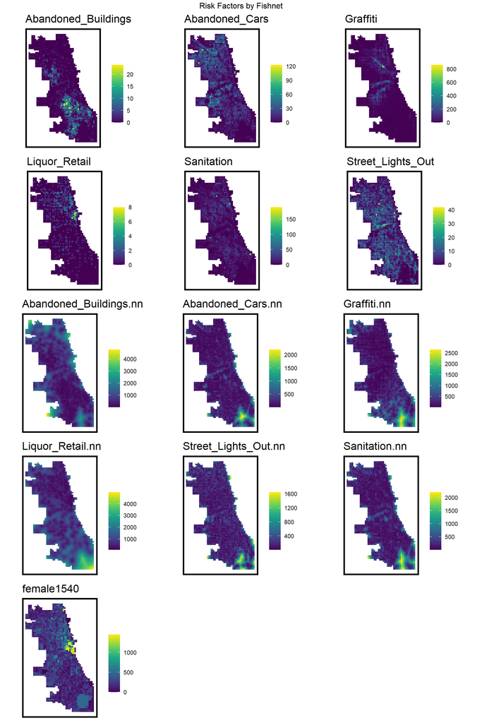

```r
vars_net.long <-
  gather(vars_net, Variable, value, -geometry, -uniqueID, -zone)

vars <- unique(vars_net.long$Variable)
mapList <- list()

for(i in vars){
  mapList[[i]] <-
    ggplot() +
      geom_sf(data = filter(vars_net.long, Variable == i), aes(fill=value), colour=NA) +
      scale_fill_viridis(name="") +
      labs(title=i) +
      mapTheme()}

do.call(grid.arrange,c(mapList, ncol=3, top="Risk Factors by Fishnet"))
```

The crime data and all features were combined together in one data frame.

```r
final_net <-
  left_join(crime_net, st_drop_geometry(vars_net), by="uniqueID")

final_net <-
  st_centroid(final_net) %>%
    st_join(dplyr::select(neighborhoods, name), by = "uniqueID") %>%
    st_join(dplyr::select(policeDistricts, District), by = "uniqueID") %>%
      st_drop_geometry() %>%
      left_join(dplyr::select(final_net, geometry, uniqueID)) %>%
      st_sf() %>%
  na.omit()
```

# 4.Spatial Autocorrelation and Spatial Process

## Local Moran’s I

The spatial autocorrelation was tested by using “Local Moran’s I”.

```r
## generates warnings from PROJ issues
## {spdep} to make polygon to neighborhoods...
final_net.nb <- poly2nb(as_Spatial(final_net), queen=TRUE)
## ... and neighborhoods to list of weigths
final_net.weights <- nb2listw(final_net.nb, style="W", zero.policy=TRUE)

# print(final_net.weights, zero.policy=TRUE)
```

```r
## see ?localmoran
local_morans <- localmoran(final_net$countAssault, final_net.weights, zero.policy=TRUE) %>%
  as.data.frame()

# join local Moran's I results to fishnet
final_net.localMorans <-
  cbind(local_morans, as.data.frame(final_net)) %>%
  st_sf() %>%
  dplyr::select(Assault_Count = countAssault,
                Local_Morans_I = Ii,
                P_Value = `Pr(z != E(Ii))`) %>%
  mutate(Significant_Hotspots = ifelse(P_Value <= 0.001, 1, 0)) %>%
  gather(Variable, Value, -geometry)
```

Below is the plot of local Moran’s I results. Relatively a few urban areas show spatial autocorrelation.

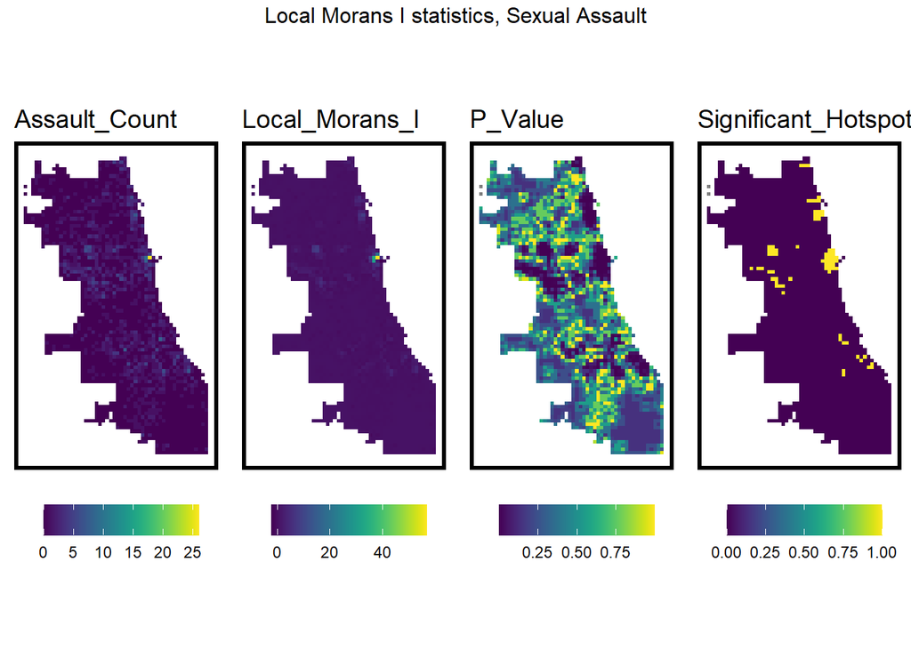

```r
## This is just for plotting
vars <- unique(final_net.localMorans$Variable)
varList <- list()

for(i in vars){
  varList[[i]] <-
    ggplot() +
      geom_sf(data = filter(final_net.localMorans, Variable == i),
              aes(fill = Value), colour=NA) +
      scale_fill_viridis(name="") +
      labs(title=i) +
      mapTheme(title_size = 14) + theme(legend.position="bottom")}

do.call(grid.arrange,c(varList, ncol = 4, top = "Local Morans I statistics, Sexual Assault"))
```

## Distance to Hot spot

Using NN distance to a hot spot location. The distance variable was added to the fishnet as a new feature of spatial process.

```r
# generates warning from NN
final_net <- final_net %>%
  mutate(S_Assault.isSig =
           ifelse(local_morans[,5] <= 0.001, 1, 0)) %>%
  mutate(S_Assault.isSig.dist =
           nn_function(st_c(st_coid(final_net)),
                       st_c(st_coid(filter(final_net,
                                           S_Assault.isSig == 1))),
                       k = 1))

## What does k = 1 represent?
```

Below is the plot of NN distance.

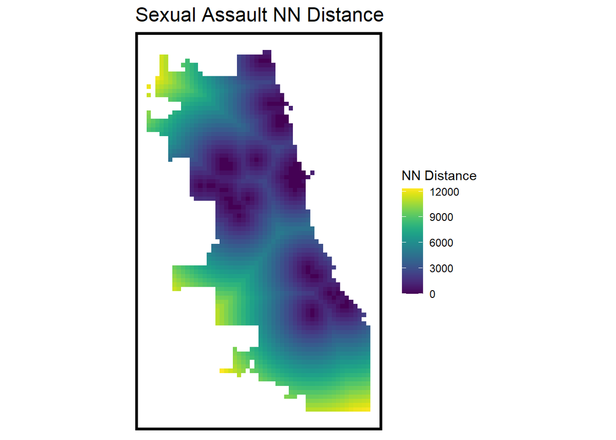

```r
ggplot() +
      geom_sf(data = final_net, aes(fill=S_Assault.isSig.dist), colour=NA) +
      scale_fill_viridis(name="NN Distance") +
      labs(title="Sexual Assault NN Distance") +
      mapTheme()
```

## Correlation tests

Below is a multiple scatterplot with correlations between dependent variable and each feature.

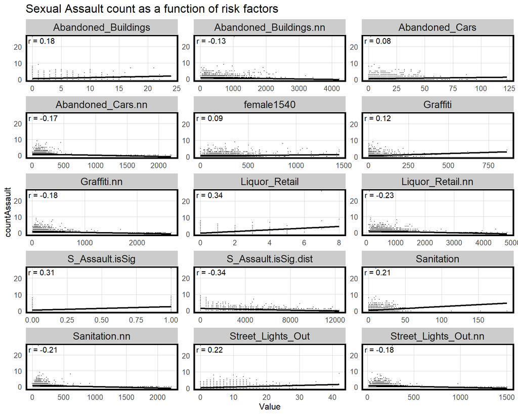

```r
correlation.long <-
  st_drop_geometry(final_net) %>%
    dplyr::select(-uniqueID, -cvID, -name, -District, -zone) %>%
    gather(Variable, Value, -countAssault)

correlation.cor <-
  correlation.long %>%
    group_by(Variable) %>%
    summarize(correlation = cor(Value, countAssault, use = "complete.obs"))

ggplot(correlation.long, aes(Value, countAssault)) +
  geom_point(size = 0.1) +
  geom_text(data = correlation.cor, aes(label = paste("r =", round(correlation, 2))),
            x=-Inf, y=Inf, vjust = 1.5, hjust = -.1) +
  geom_smooth(method = "lm", se = FALSE, colour = "black") +
  facet_wrap(~Variable, ncol = 3, scales = "free") +
  labs(title = "Sexual Assault count as a function of risk factors") +
  plotTheme()
```

# 5. Modeling and Cross Validation

## Cross Validation

Poisson regression was used as the regression model. First let’s take a look at the distribution of sexual assault count in the fishnet.

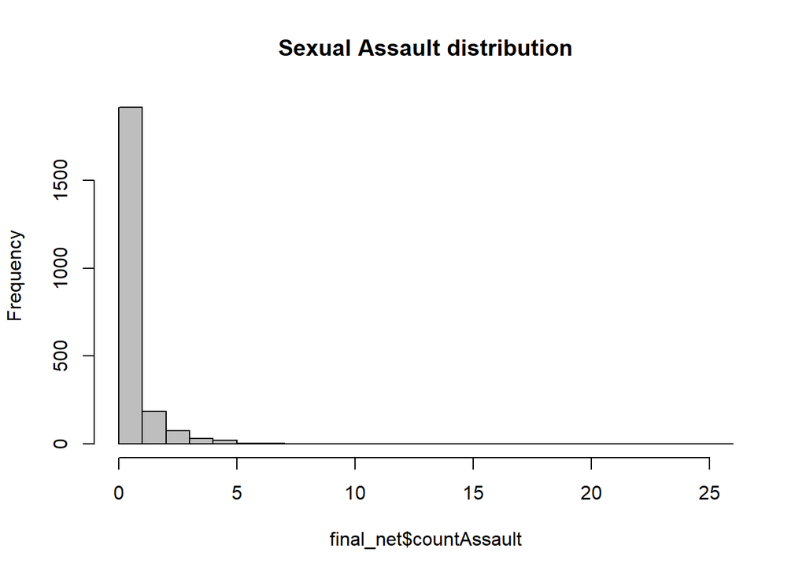

```r
hist(final_net$countAssault, col="grey", breaks = 30, main = "Sexual Assault distribution")
```

2 regression model were run. One is random k-fold cross validation. Another is cross validation by neighborhood.

```r
reg.ss.vars <- c("Abandoned_Buildings.nn", "Abandoned_Cars.nn", "Graffiti.nn",
                 "Liquor_Retail.nn", "Street_Lights_Out.nn", "Sanitation.nn",
                 "S_Assault.isSig", "S_Assault.isSig.dist","zone","female1540")

## cv Random k-fold
reg.ss.cv <- crossValidate(
  dataset = final_net,
  id = "cvID",
  dependentVariable = "countAssault",
  indVariables = reg.ss.vars) %>%
    dplyr::select(cvID = cvID, countAssault, Prediction, geometry) %>%
  mutate(legend = "Random k-fold")

## cv by neighborhoods
reg.ss.spatialCV <- crossValidate(
  dataset = final_net,
  id = "name",
  dependentVariable = "countAssault",
  indVariables = reg.ss.vars) %>%
    dplyr::select(cvID = name, countAssault, Prediction, geometry) %>%
  mutate(legend = 'Spatial cv')
```

```r
reg.summary <-
  rbind(
    mutate(reg.ss.cv,        Error = Prediction - countAssault,
                             Regression = "Random k-fold CV: Spatial Process"),

    mutate(reg.ss.spatialCV, Error = Prediction - countAssault,
                             Regression = "Spatial LOGO-CV: Spatial Process")) %>%
    st_sf()
```

## Model Accuracy

Below is the MAE for both regression. The random k-fold regression performs better than spatial cv regression.

```r
# calculate errors by NEIGHBORHOOD
error_by_reg_and_fold <-
  reg.summary %>%
    group_by(Regression, cvID) %>%
    summarize(Mean_Error = mean(Prediction - countAssault, na.rm = T),
              MAE = mean(abs(Mean_Error), na.rm = T),
              SD_MAE = mean(abs(Mean_Error), na.rm = T)) %>%
  ungroup()

error_by_reg_and_fold %>%
  arrange(desc(MAE))
error_by_reg_and_fold %>%
  arrange(MAE)
```

```r
st_drop_geometry(error_by_reg_and_fold) %>%
  group_by(Regression) %>%
    summarize(Mean_MAE = round(mean(MAE), 2),
              SD_MAE = round(sd(MAE), 2)) %>%
  kable() %>%
    kable_styling("striped", full_width = F)
```

| Regression | Mean_MAE | SD_MAE |
| --- | --- | --- |
| Random k-fold CV: Spatial Process | 0.16 | 0.16 |
| Spatial LOGO-CV: Spatial Process | 0.34 | 0.47 |

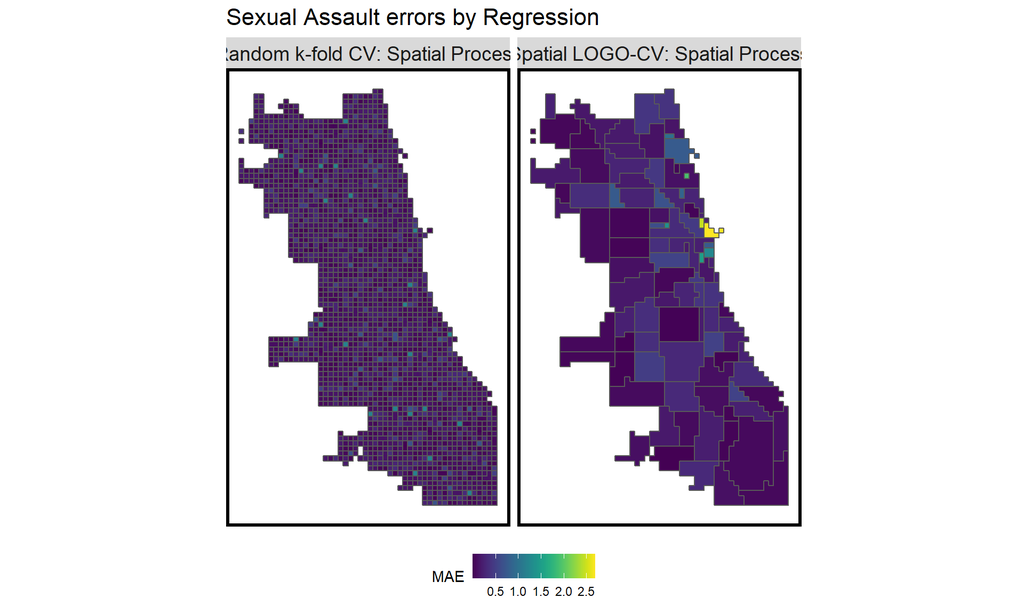

```r
error_by_reg_and_fold %>%
  ggplot() +
    geom_sf(aes(fill = MAE)) +
    facet_wrap(~Regression) +
    scale_fill_viridis() +
    labs(title = "Sexual Assault errors by Regression") +
    mapTheme() + theme(legend.position="bottom")
```

```r
tracts18 <-
  get_acs(geography = "tract", variables = c("B01001_001E","B01001A_001E"),
          year = 2018, state=17, county=031, geometry=T) %>%
  st_transform('ESRI:102271')  %>%
  dplyr::select(variable, estimate, GEOID) %>%
  spread(variable, estimate) %>%
  rename(TotalPop = B01001_001,
         NumberWhites = B01001A_001) %>%
  mutate(percentWhite = NumberWhites / TotalPop,
         raceContext = ifelse(percentWhite > .5, "Majority_White", "Majority_Non_White")) %>%
  .[neighborhoods,]

reg.summary %>%
    st_centroid() %>%
    st_join(tracts18) %>%
    na.omit() %>%
      st_drop_geometry() %>%
      group_by(Regression, raceContext) %>%
      summarize(mean.Error = mean(Error, na.rm = T)) %>%
      spread(raceContext, mean.Error) %>%
      kable(caption = "Mean Error by neighborhood racial context") %>%
        kable_styling("striped", full_width = F)
```

[output not shown]

# 6. Density vs predictions

In this section, the kernel density and risk predictions was compared to see which method is better.

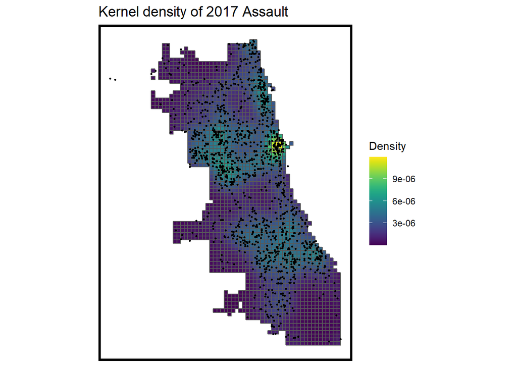

```r
# demo of kernel width
burg_ppp <- as.ppp(st_coordinates(S_ASSAULT), W = st_bbox(final_net))
burg_KD.1000 <- spatstat.core::density.ppp(burg_ppp, 1000)

as.data.frame(burg_KD.1000) %>%
  st_as_sf(coords = c("x", "y"), crs = st_crs(final_net)) %>%
  aggregate(., final_net, mean) %>%
   ggplot() +
     geom_sf(aes(fill=value)) +
     geom_sf(data = sample_n(S_ASSAULT, 1422), size = .5) +
     scale_fill_viridis(name = "Density") +
     labs(title = "Kernel density of 2017 Assault") +
     mapTheme(title_size = 14)
```

## Get 2018 crime data

To test both model, 2018 crime data was used.

```r
S_ASSAULT18 <-
  read.socrata("https://data.cityofchicago.org/Public-Safety/Crimes-2018/3i3m-jwuy") %>%
  filter(Primary.Type == "CRIM SEXUAL ASSAULT" ) %>%
  mutate(x = gsub("[()]", "", Location)) %>%
  separate(x,into= c("Y","X"), sep=",") %>%
  mutate(X = as.numeric(X),
         Y = as.numeric(Y)) %>%
  na.omit %>%
  st_as_sf(coords = c("X", "Y"), crs = 4326, agr = "constant") %>%
  st_transform('ESRI:102271') %>%
  distinct() %>%
  .[fishnet,]
```

```r
burg_KDE_sum <- as.data.frame(burg_KD.1000) %>%
  st_as_sf(coords = c("x", "y"), crs = st_crs(final_net)) %>%
  aggregate(., final_net, mean)
kde_breaks <- classIntervals(burg_KDE_sum$value,
                             n = 5, "fisher")

burg_KDE_sf <- burg_KDE_sum %>%
  mutate(label = "Kernel Density",
         Risk_Category = classInt::findCols(kde_breaks),
         Risk_Category = case_when(
           Risk_Category == 5 ~ "5th",
           Risk_Category == 4 ~ "4th",
           Risk_Category == 3 ~ "3rd",
           Risk_Category == 2 ~ "2nd",
           Risk_Category == 1 ~ "1st")) %>%
  cbind(
    aggregate(
      dplyr::select(S_ASSAULT18) %>% mutate(burgCount = 1), ., sum) %>%
    mutate(burgCount = replace_na(burgCount, 0))) %>%
  dplyr::select(label, Risk_Category, burgCount)
```

```r
ml_breaks <- classIntervals(reg.ss.spatialCV$Prediction,
                             n = 5, "fisher")
burg_risk_sf <-
  reg.ss.spatialCV %>%
  mutate(label = "Risk Predictions",
         Risk_Category =classInt::findCols(ml_breaks),
         Risk_Category = case_when(
           Risk_Category == 5 ~ "5th",
           Risk_Category == 4 ~ "4th",
           Risk_Category == 3 ~ "3rd",
           Risk_Category == 2 ~ "2nd",
           Risk_Category == 1 ~ "1st")) %>%
  cbind(
    aggregate(
      dplyr::select(S_ASSAULT18) %>% mutate(burgCount = 1), ., sum) %>%
      mutate(burgCount = replace_na(burgCount, 0))) %>%
  dplyr::select(label,Risk_Category, burgCount)
```

Below shows the risk level of both kernel density and risk predictions method.

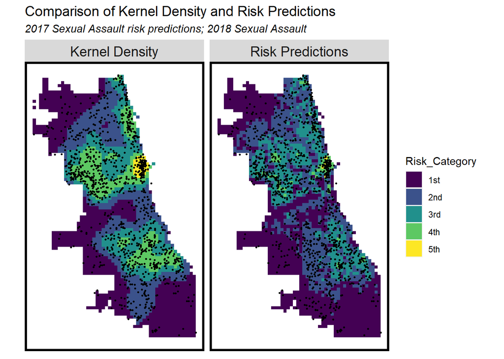

```r
rbind(burg_KDE_sf, burg_risk_sf) %>%
  na.omit() %>%
  gather(Variable, Value, -label, -Risk_Category, -geometry) %>%
  ggplot() +
    geom_sf(aes(fill = Risk_Category), colour = NA) +
    geom_sf(data = sample_n(S_ASSAULT18, 1338), size = .5, colour = "black") +
    facet_wrap(~label, ) +
    scale_fill_viridis(discrete = TRUE) +
    labs(title="Comparison of Kernel Density and Risk Predictions",
         subtitle="2017 Sexual Assault risk predictions; 2018 Sexual Assault") +
    mapTheme(title_size = 14)
```

To compare 2 method, the accuracy of both method was compared in each risk level. The result shows that the risk prediction performs much better in the first 3 levels while kernel density performs better in the last 2 levels.

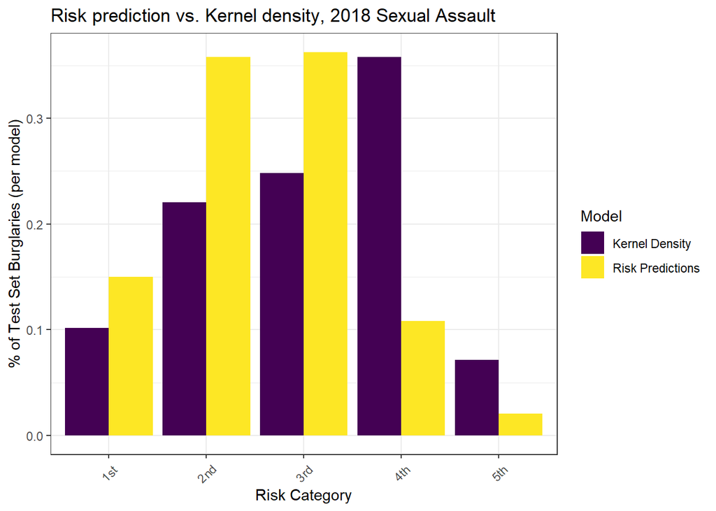

```r
rbind(burg_KDE_sf, burg_risk_sf) %>%
  st_drop_geometry() %>%
  na.omit() %>%
  gather(Variable, Value, -label, -Risk_Category) %>%
  group_by(label, Risk_Category) %>%
  summarize(countBurglaries = sum(Value)) %>%
  ungroup() %>%
  group_by(label) %>%
  mutate(Pcnt_of_test_set_crimes = countBurglaries / sum(countBurglaries)) %>%
    ggplot(aes(Risk_Category,Pcnt_of_test_set_crimes)) +
      geom_bar(aes(fill=label), position="dodge", stat="identity") +
      scale_fill_viridis(discrete = TRUE, name = "Model") +
      labs(title = "Risk prediction vs. Kernel density, 2018 Sexual Assault",
           y = "% of Test Set Burglaries (per model)",
           x = "Risk Category") +
  theme_bw() +
      theme(axis.text.x = element_text(angle = 45, vjust = 0.5))
```

# 7.Conclusion and Recommendation

I don’t recommend this algorithm be put into production for 2 main reasons. First, the new method fails to perform better in the high risk levels. The reason of this might be that the distribution of sexual assault shows really few spatial process according to Local Moran’s I. The distribution may be just simply related to the population density rather than “broken window” area or female population. That’s why the kernel density method performs better. Second, sexual assault as a special crime type, is significantly effected by the selection bias (victims’ willing to report), which may make the reported incidents really random and hard to find the spatial process behind it. From this aspect, the value of this report is the conclusion that sexual assault does not lend itself to prediction by policing prediction algorithms.